In this notebook, we will predict the likelihood of a heart attack.

# Task 2

## 2.

As we can see, explanations for the first three observations from the dataset vary for age feature, but are very similar for cholesterol if we use Random Forest Classifier.

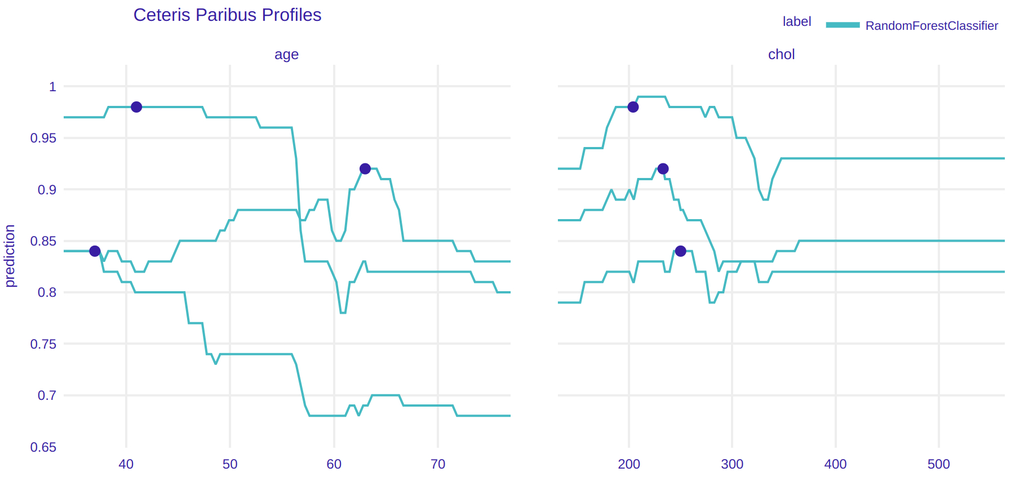

This is different for the Logistic Regression model - the explanations for age are similar here. They also increase while for Random Forest they rather decrease...

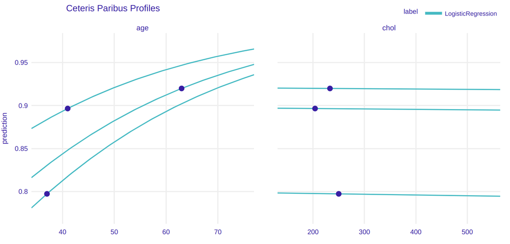

## 3.

Between the age of 40 and 70, the explanations diverge. When the one increases, the other one decreases.

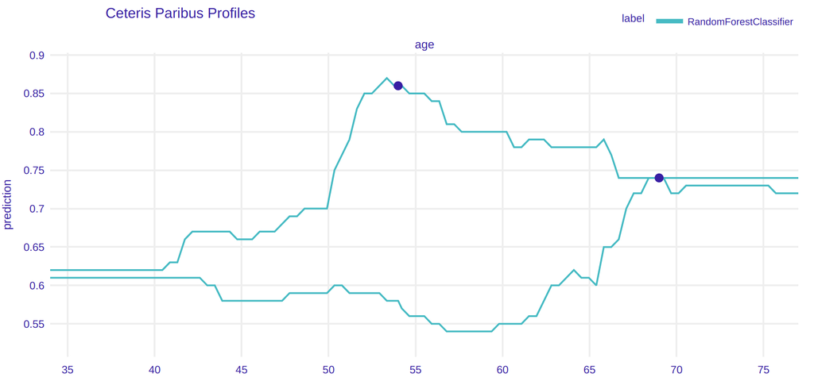

## 4.

The results obtained on the mean of the dataset and the cholesterol feature are similar, but the PDP seems to be slightly less stable with its predictions. They are also a little bit lower.

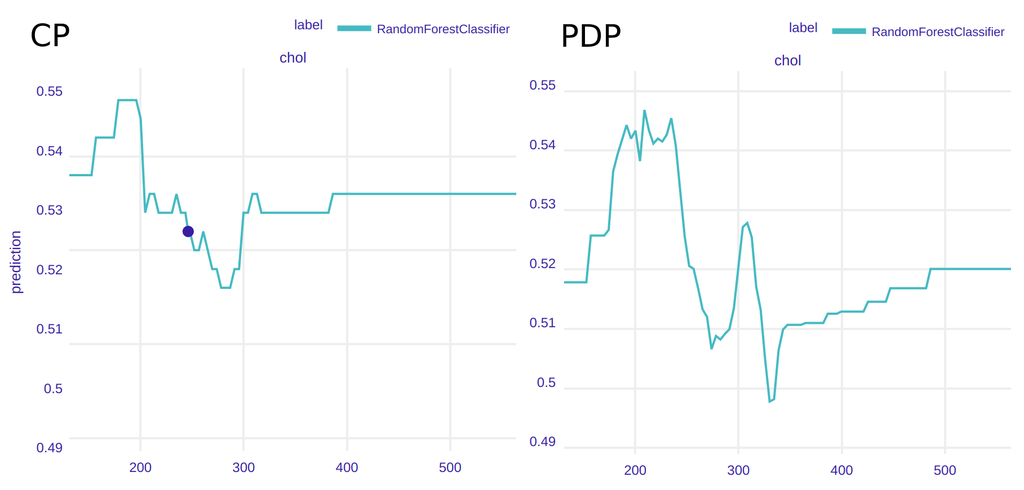

## 5.

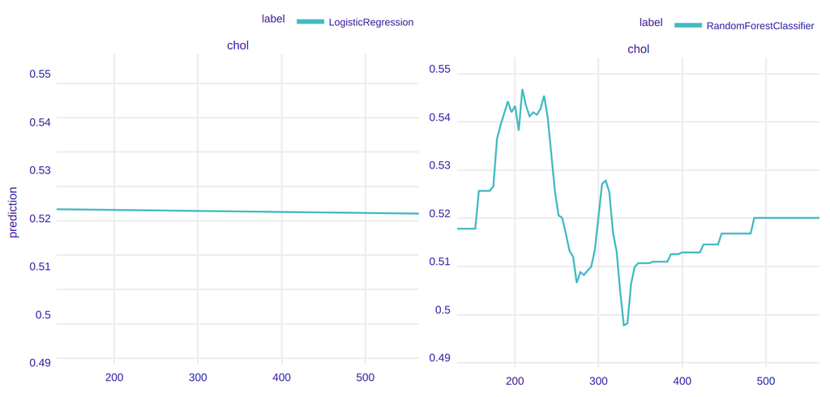

# Appendix

```python
#@title Imports
import dalex as dx
import alibi

import sklearn
import pandas as pd
import numpy as np

from sklearn.linear_model import LogisticRegression
from sklearn.ensemble import RandomForestClassifier
from sklearn.model_selection import train_test_split

import warnings
warnings.filterwarnings("ignore")
```

## Data download

Please, write your Kaggle username and key below.

```python
import json
import os
from pathlib import Path

# your api key
api_key = {
'username':"username" ,  # Edit this line.
'key':"key"}  # Edit this line.

# uses pathlib Path
kaggle_path = Path('/root/.kaggle')
os.makedirs(kaggle_path, exist_ok=True)

# opens file and dumps python dict to json object
with open (kaggle_path/'kaggle.json', 'w') as handl:
    json.dump(api_key,handl)

os.chmod(kaggle_path/'kaggle.json', 600)
```

```python
from kaggle.api.kaggle_api_extended import KaggleApi

api = KaggleApi()
api.authenticate()
filename = 'heart.csv'
api.dataset_download_file('rashikrahmanpritom/heart-attack-analysis-prediction-dataset', file_name=filename, path='./')
```

```
True
```

```python
df = pd.read_csv(filename).dropna()
df
```

|  | age | sex | cp | trtbps | chol | fbs | restecg | thalachh | exng | oldpeak | slp | caa | thall | output |
| --- | --- | --- | --- | --- | --- | --- | --- | --- | --- | --- | --- | --- | --- | --- |
| 0 | 63 | 1 | 3 | 145 | 233 | 1 | 0 | 150 | 0 | 2.3 | 0 | 0 | 1 | 1 |
| 1 | 37 | 1 | 2 | 130 | 250 | 0 | 1 | 187 | 0 | 3.5 | 0 | 0 | 2 | 1 |
| 2 | 41 | 0 | 1 | 130 | 204 | 0 | 0 | 172 | 0 | 1.4 | 2 | 0 | 2 | 1 |
| 3 | 56 | 1 | 1 | 120 | 236 | 0 | 1 | 178 | 0 | 0.8 | 2 | 0 | 2 | 1 |
| 4 | 57 | 0 | 0 | 120 | 354 | 0 | 1 | 163 | 1 | 0.6 | 2 | 0 | 2 | 1 |
| ... | ... | ... | ... | ... | ... | ... | ... | ... | ... | ... | ... | ... | ... | ... |
| 298 | 57 | 0 | 0 | 140 | 241 | 0 | 1 | 123 | 1 | 0.2 | 1 | 0 | 3 | 0 |
| 299 | 45 | 1 | 3 | 110 | 264 | 0 | 1 | 132 | 0 | 1.2 | 1 | 0 | 3 | 0 |
| 300 | 68 | 1 | 0 | 144 | 193 | 1 | 1 | 141 | 0 | 3.4 | 1 | 2 | 3 | 0 |
| 301 | 57 | 1 | 0 | 130 | 131 | 0 | 1 | 115 | 1 | 1.2 | 1 | 1 | 3 | 0 |
| 302 | 57 | 0 | 1 | 130 | 236 | 0 | 0 | 174 | 0 | 0.0 | 1 | 1 | 2 | 0 |

303 rows × 14 columns

```python
df.describe().round(decimals=0)
```

|  | age | sex | cp | trtbps | chol | fbs | restecg | thalachh | exng | oldpeak | slp | caa | thall | output |
| --- | --- | --- | --- | --- | --- | --- | --- | --- | --- | --- | --- | --- | --- | --- |
| count | 303.0 | 303.0 | 303.0 | 303.0 | 303.0 | 303.0 | 303.0 | 303.0 | 303.0 | 303.0 | 303.0 | 303.0 | 303.0 | 303.0 |
| mean | 54.0 | 1.0 | 1.0 | 132.0 | 246.0 | 0.0 | 1.0 | 150.0 | 0.0 | 1.0 | 1.0 | 1.0 | 2.0 | 1.0 |
| std | 9.0 | 0.0 | 1.0 | 18.0 | 52.0 | 0.0 | 1.0 | 23.0 | 0.0 | 1.0 | 1.0 | 1.0 | 1.0 | 0.0 |
| min | 29.0 | 0.0 | 0.0 | 94.0 | 126.0 | 0.0 | 0.0 | 71.0 | 0.0 | 0.0 | 0.0 | 0.0 | 0.0 | 0.0 |
| 25% | 48.0 | 0.0 | 0.0 | 120.0 | 211.0 | 0.0 | 0.0 | 134.0 | 0.0 | 0.0 | 1.0 | 0.0 | 2.0 | 0.0 |
| 50% | 55.0 | 1.0 | 1.0 | 130.0 | 240.0 | 0.0 | 1.0 | 153.0 | 0.0 | 1.0 | 1.0 | 0.0 | 2.0 | 1.0 |
| 75% | 61.0 | 1.0 | 2.0 | 140.0 | 274.0 | 0.0 | 1.0 | 166.0 | 1.0 | 2.0 | 2.0 | 1.0 | 3.0 | 1.0 |
| max | 77.0 | 1.0 | 3.0 | 200.0 | 564.0 | 1.0 | 2.0 | 202.0 | 1.0 | 6.0 | 2.0 | 4.0 | 3.0 | 1.0 |

## 0.

```python
X = df.drop(columns='output')
X = pd.get_dummies(X, columns=['sex', 'cp', 'slp'], drop_first=True)
y = df.output

X_train, X_test, y_train, y_test = train_test_split(X, y, test_size=0.33, random_state=42)
```

```python
rfc_model = RandomForestClassifier()
rfc_model.fit(X_train, y_train)
```

```python
lr_model = LogisticRegression()
lr_model.fit(X_train, y_train)
```

## 1.

```python
rfc_model.predict_proba(X_test.iloc[:3,:])[:,1]
```

```
array([0.1 , 0.55, 0.52])
```

```python
lr_model.predict_proba(X_test.iloc[:3,:])[:,1]
```

```
array([0.12458347, 0.51905201, 0.80671743])
```

## 2.

```python
rfc_explainer = dx.Explainer(rfc_model, X_train, y_train)
lr_explainer = dx.Explainer(lr_model, X_train, y_train)
```

```python
cp1 = rfc_explainer.predict_profile(new_observation=X.iloc[:3,:])
cp2 = lr_explainer.predict_profile(new_observation=X.iloc[:3,:])
```

```python
cp1.plot(variables=["age", "chol"])
```

```python
cp2.plot(variables=["age", "chol"])
```

## 3.

```python
two_random_numbers = np.random.choice(range(len(X)), 2, replace=False)
print(two_random_numbers)
cp1 = rfc_explainer.predict_profile(new_observation=X.iloc[two_random_numbers,:])
cp1.plot(variables=["age"])
```

## 4.

```python
cp1 = rfc_explainer.predict_profile(new_observation=X.mean())
cp1.plot(variables=["age", "chol"])
```

```python
pdp1 = rfc_explainer.model_profile()
pdp1.plot(variables=["age", "chol"])
```

## 5.

```python
pdp2 = lr_explainer.model_profile()
pdp2.plot(variables=["age", "chol"])
```